# Tutorial for BilinearModels package

Jeffrey W. Miller

## Introduction

Generalized bilinear models (GBMs) are a flexible extension of generalized linear models (GLMs) to include latent factors as well as row covariates, column covariates, and interactions to analyze matrix data (Choulakian, 1996; Miller and Carter, 2020).

This tutorial shows how to use the BilinearModels.jl Julia package to perform estimation and inference in negative binomial GBMs for count data. Please cite Miller and Carter (2020) if you use the BilinearModels.jl package for research leading to a publication.

In a GBM, the data matrix $Y = (Y_{i j})\in\mathbb{R}^{I\times J}$ is modeled by parametrizing the mean matrix $\mathrm{E}(Y)$ such that

$$ g(\mathrm{E}(Y)) = X A^\textrm{T} + B Z^\textrm{T} + X C Z^\textrm{T} + U D V^\textrm{T} \tag{1} $$

where $X\in\mathbb{R}^{I\times K}$ and $Z\in\mathbb{R}^{J\times L}$ are matrices of covariates and $g$ is a link function that is applied element-wise. The "bilinear" part $U D V^\textrm{T}$ is a rank $M$ matrix that captures latent effects due, for example, to unobserved covariates such as batch. The BilinearModels.jl package currently implements GBMs using a negative binomial outcome with log link, $g(\mu) = \log(\mu)$, specifically,

$$ Y_{i j} \sim \mathrm{NegBin}(\mu_{i j}, r_{i j}) $$

where $\mu_{i j} = \mathrm{E}(Y_{i j})$ is the mean and $1/r_{i j}$ is the dispersion, which we parametrize as $1/r_{i j} = \exp(s_i+t_j+\omega)$. We define $S = (s_1,\ldots,s_I)^\textrm{T}$ and $T = (t_1,\ldots,t_J)^\textrm{T}$. See Miller and Carter (2020) for details.

[figure not shown]

The package provides two main functions: `fit` and `infer`. The `fit` function takes $Y$, $X$, $Z$, and $M$ as inputs, and returns estimates of all the parameters ($A$, $B$, $C$, $D$, $U$, $V$, $S$, $T$, and $\omega$). The `infer` function takes $Y$, $X$, $Z$, and the parameter estimates as inputs, and returns approximate standard errors.

## Overview of the tutorial

GBMs are highly versatile. Since various special cases of GBMs are useful for a range of tasks, we illustrate with a range of models from simpler to more complex.

| Task / Illustration | Sample covariates | Feature covariates | Latent factors |
| --- | --- | --- | --- |
| Simple normalization and exploratory analysis |  |  |  |
| Adjusting for sample covariates | X |  |  |
| Adjusting for feature covariates | X | X |  |
| Testing for differences between groups | X | X |  |
| Testing for association | X | X | X |
| Computing partial residuals | X | X | X |
| Dimension reduction using latent factors | X | X | X |

## Setup

### Installing the BilinearModels.jl package

First, download and install [Julia](https://julialang.org/). Then start Julia and enter the following commands at the `julia>` prompt to install the BilinearModels.jl package:

```julia
using Pkg
Pkg.add(url="https://github.com/jwmi/BilinearModels.jl")
```

```
   Updating git-repo `https://github.com/jwmi/BilinearModels.jl`
```

```
   Updating registry at `C:\Users\jwmil\.julia\registries\General`
```

```
   Updating git-repo `https://github.com/JuliaRegistries/General.git`
```

```
Fetching: [========================================>]  100.0 %
```

[output not shown]

```julia
using BilinearModels
```

```
┌ Info: Precompiling BilinearModels [f64e3ec5-78ee-408e-b4f6-5e3b431f6660]
└ @ Base loading.jl:1278
```

As a quick test to make sure things are working, try this:

```julia
Y = [1 2 3; 4 5 6; 7 8 0]
I,J = size(Y)
X = ones(I,1)
Z = ones(J,1)
A,B,C,D,U,V,S,T,omega,logp = BilinearModels.fit(Y,X,Z,0)
A
```

```
iteration 1: logp = -32.181561516520645
iteration 2: logp = -32.06094964489715
iteration 3: logp = -32.02450562203871
iteration 4: logp = -32.00936718102702
iteration 5: logp = -32.002571675212614
iteration 6: logp = -31.999367910889188
iteration 7: logp = -31.997817594791158
iteration 8: logp = -31.997057070632096
iteration 9: logp = -31.99668136745074
iteration 10: logp = -31.996495098807483
iteration 11: logp = -31.996402577578284
iteration 12: logp = -31.996356577164565
iteration 13: logp = -31.99633369482534
Finished.
```

```
3×1 Array{Float64,2}:
 -0.11118582286764742
  0.11506609564808493
 -0.0038802727804375103
```

### Installing other packages for the tutorial

We will also use some other Julia packages in this tutorial. To install these, do:

```julia
using Pkg
Pkg.add(["Statistics","Distributions","CSV","RData","GLM","CategoricalArrays","DataFrames","PyPlot"])
```

[output not shown]

[output cut: 20 more lines]

[output not shown]

### Loading example data

As a running example, we will use 412 RNA-seq samples from heart tissue provided by the [Recount2 project](https://jhubiostatistics.shinyapps.io/recount/) (Collado-Torres et al., 2017), originally collected as part of the Genotype-Tissue Expression (GTEx) project (Melé et al., 2015).

Download the following files to a folder on your computer:

- [Sample information file (344 KB)](https://raw.githubusercontent.com/jwmi/BilinearModelsExamples/main/tutorial/gtex_sample_info-heart.tsv)
- [Gene information file (2 MB)](https://raw.githubusercontent.com/jwmi/BilinearModelsExamples/main/tutorial/gtex_gene_info-heart.tsv)
- [Data file (15.7 MB)](https://github.com/jwmi/BilinearModelsExamples/raw/main/tutorial/gtex_data-heart.rda)
- [Miscellaneous helper functions](https://github.com/jwmi/BilinearModelsExamples/raw/main/tutorial/helper.jl)

In this data set, there is a row for each gene (i.e., each feature) and a column for each sample. We load these data as follows.

```julia
cd("C:\\Users\\jwmil\\gdrive\\BilinearModelsExamples\\tutorial")  # change directory to the location of these files

include("helper.jl");  # load helper functions into Julia
```

```julia
Y = load("gtex_data-heart.rda")["counts"]  # load data matrix
```

```
20088×412 Array{Int32,2}:
  182   179    412   133   141    282  …    304  211    381    215   253  151
    4     5      1     1     4      5         4    2      3      1     3    6
  561   574    534   490   375    758       700  673    505    610   522  559
  293   263    334   218   178    137       354  201    209    292   201  206
  137   124    213    99    95     55       157   96    146    176    97   89
  127   281    834   146   424    169  …    438   54    107    227   270  158
  732  1073  34158   376  1394  25192     12049  722  18834  19327  5649  567
 1147  1211    979  1011   599    882      1385  694    903    641   873  865
  772   549    621   474   244    498       528  382    477    481   521  557
  350   399    783   333   361    399       457  225    836    592   339  267
  136   123    254   123    87     85  …    169  119    160    101    63   70
 1023  1056    607  1041   288    642      1243  537    331    397   462  794
  582   546    765   617   563   1058       921  667    703   1072   781  593
    ⋮                               ⋮  ⋱                               ⋮
   25    27     53    35    33     21        14   18     54     48    35   24
   53    47    296    37    49    206        94   48    397    274    94   39
   12     6     10     9     5     30         8   13     13     18    17    7
  155   188    403   168   144    178       192  129    126    297   186  135
  181   212    305   162   155    100  …    145  239    149    282    98  100
   97    87    166    97    67    171       168   71     92     99    54   78
    2     1      7     2     2      2         1    3      2      4     3    1
  112   123    189    81    62     72       147   53    144     81    86   83
   44    32      5    34    55      1         5   17      1      5    10   23
   61    30    100    28    18     23  …     86   47     29     41    28   48
    6     6     34     8     8     30        17    4     37     16    35    3
   19    17     28    29    21     21        22    6     20     17    17   24
```

```julia
sample_info = CSV.read("gtex_sample_info-heart.tsv", DataFrame; delim='\t')  # load sample information file
```

|  | project String | sample String | experiment String | run String | read_count_as_reported_by_sra Int64 | reads_downloaded Int64 |
| --- | --- | --- | --- | --- | --- | --- |
| 1 | SRP012682 | SRS333474 | SRX199032 | SRR606939 | 189907530 | 170497100 |
| 2 | SRP012682 | SRS648313 | SRX629479 | SRR1468613 | 119736648 | 119736648 |
| 3 | SRP012682 | SRS408501 | SRX260988 | SRR815184 | 115367100 | 115367100 |
| 4 | SRP012682 | SRS634869 | SRX591515 | SRR1381693 | 109208494 | 109208494 |
| 5 | SRP012682 | SRS648280 | SRX629144 | SRR1467904 | 96421614 | 96421614 |
| 6 | SRP012682 | SRS644516 | SRX617942 | SRR1442648 | 95958592 | 95958592 |
| 7 | SRP012682 | SRS649562 | SRX636407 | SRR1486174 | 94014668 | 94014668 |
| 8 | SRP012682 | SRS629385 | SRX576409 | SRR1349433 | 91835392 | 91835392 |
| 9 | SRP012682 | SRS625582 | SRX563501 | SRR1321283 | 90353688 | 90353688 |
| 10 | SRP012682 | SRS644121 | SRX615541 | SRR1435584 | 83415330 | 83415330 |
| 11 | SRP012682 | SRS638188 | SRX601993 | SRR1406265 | 81440676 | 81440676 |
| 12 | SRP012682 | SRS631312 | SRX583323 | SRR1366367 | 80669714 | 80669714 |
| 13 | SRP012682 | SRS645978 | SRX624406 | SRR1458026 | 76180224 | 76180224 |
| 14 | SRP012682 | SRS525391 | SRX417652 | SRR1094192 | 74473140 | 74473140 |
| 15 | SRP012682 | SRS637682 | SRX598670 | SRR1397180 | 61574636 | 61574636 |
| 16 | SRP012682 | SRS389517 | SRX222148 | SRR657492 | 232226234 | 232226234 |
| 17 | SRP012682 | SRS389970 | SRX223476 | SRR662665 | 118866350 | 118866350 |
| 18 | SRP012682 | SRS408725 | SRX261517 | SRR818530 | 116347486 | 116347486 |
| 19 | SRP012682 | SRS408655 | SRX261362 | SRR817563 | 110339736 | 110339736 |
| 20 | SRP012682 | SRS374862 | SRX203793 | SRR613462 | 100747704 | 100747704 |
| 21 | SRP012682 | SRS638127 | SRX601612 | SRR1405206 | 100380886 | 100380886 |
| 22 | SRP012682 | SRS645799 | SRX622835 | SRR1454136 | 100230322 | 100230322 |
| 23 | SRP012682 | SRS374774 | SRX203603 | SRR612875 | 98192256 | 98192256 |
| 24 | SRP012682 | SRS408152 | SRX259963 | SRR808327 | 86218376 | 86218376 |
| 25 | SRP012682 | SRS638298 | SRX602672 | SRR1408227 | 69535388 | 69535388 |
| 26 | SRP012682 | SRS524962 | SRX413649 | SRR1086304 | 61451894 | 61451894 |
| 27 | SRP012682 | SRS524905 | SRX412979 | SRR1084965 | 55053662 | 55053662 |
| 28 | SRP012682 | SRS623958 | SRX558526 | SRR1310563 | 114387252 | 114387252 |
| 29 | SRP012682 | SRS333601 | SRX199209 | SRR602437 | 111269080 | 111269080 |
| 30 | SRP012682 | SRS389834 | SRX223046 | SRR663404 | 102713188 | 102713188 |
| ⋮ | ⋮ | ⋮ | ⋮ | ⋮ | ⋮ | ⋮ |

```julia
gene_info = CSV.read("gtex_gene_info-heart.tsv", DataFrame; delim='\t')  # load gene information file
```

|  | gene_id String | symbol String | seq_len Int64 | seqname String | strand String | num_A Int64 | num_C Int64 | num_G Int64 | num_T Int64 |
| --- | --- | --- | --- | --- | --- | --- | --- | --- | --- |
| 1 | ENSG00000000003.14 | TSPAN6 | 4535 | chrX | - | 1280 | 835 | 1054 | 1366 |
| 2 | ENSG00000000005.5 | TNMD | 1610 | chrX | + | 492 | 334 | 350 | 434 |
| 3 | ENSG00000000419.12 | DPM1 | 1207 | chr20 | - | 362 | 210 | 270 | 365 |
| 4 | ENSG00000000457.13 | SCYL3 | 6883 | chr1 | - | 2058 | 1432 | 1416 | 1977 |
| 5 | ENSG00000000460.16 | C1orf112 | 5967 | chr1 | + | 1647 | 1354 | 1211 | 1755 |
| 6 | ENSG00000000938.12 | FGR | 3474 | chr1 | - | 768 | 973 | 1018 | 715 |
| 7 | ENSG00000000971.15 | CFH | 8145 | chr1 | + | 2685 | 1349 | 1595 | 2516 |
| 8 | ENSG00000001036.13 | FUCA2 | 2793 | chr6 | - | 796 | 576 | 637 | 784 |
| 9 | ENSG00000001084.10 | GCLC | 8463 | chr6 | - | 2319 | 1822 | 1904 | 2418 |
| 10 | ENSG00000001167.14 | NFYA | 3811 | chr6 | + | 1086 | 804 | 911 | 1010 |
| 11 | ENSG00000001460.17 | STPG1 | 8511 | chr1 | - | 2153 | 2146 | 2085 | 2127 |
| 12 | ENSG00000001461.16 | NIPAL3 | 9404 | chr1 | + | 2471 | 2131 | 2281 | 2521 |
| 13 | ENSG00000001497.16 | LAS1L | 5589 | chrX | - | 1344 | 1492 | 1384 | 1369 |
| 14 | ENSG00000001561.6 | ENPP4 | 4651 | chr6 | + | 1497 | 758 | 844 | 1552 |
| 15 | ENSG00000001617.11 | SEMA3F | 4826 | chr3 | + | 922 | 1553 | 1478 | 873 |
| 16 | ENSG00000001626.14 | CFTR | 8517 | chr7 | + | 2623 | 1627 | 1896 | 2371 |
| 17 | ENSG00000001629.9 | ANKIB1 | 7130 | chr7 | + | 2190 | 1433 | 1486 | 2021 |
| 18 | ENSG00000001630.15 | CYP51A1 | 4074 | chr7 | - | 1138 | 846 | 896 | 1194 |
| 19 | ENSG00000001631.15 | KRIT1 | 6204 | chr7 | - | 1994 | 1152 | 1199 | 1859 |
| 20 | ENSG00000002016.17 | RAD52 | 4190 | chr12 | - | 979 | 1051 | 1072 | 1088 |
| 21 | ENSG00000002330.13 | BAD | 1708 | chr11 | - | 333 | 555 | 550 | 270 |
| 22 | ENSG00000002549.12 | LAP3 | 3785 | chr4 | + | 1018 | 838 | 863 | 1066 |
| 23 | ENSG00000002586.18 | CD99 | 3284 | chrX | + | 746 | 836 | 864 | 838 |
| 24 | ENSG00000002587.9 | HS3ST1 | 8166 | chr4 | - | 2240 | 1966 | 1935 | 2025 |
| 25 | ENSG00000002726.20 | AOC1 | 3824 | chr7 | + | 854 | 1179 | 1064 | 727 |
| 26 | ENSG00000002745.12 | WNT16 | 3261 | chr7 | + | 993 | 630 | 736 | 902 |
| 27 | ENSG00000002746.14 | HECW1 | 13965 | chr7 | + | 3773 | 3397 | 3276 | 3519 |
| 28 | ENSG00000002822.15 | MAD1L1 | 7230 | chr7 | - | 1428 | 2003 | 2388 | 1411 |
| 29 | ENSG00000002834.17 | LASP1 | 7061 | chr17 | + | 1438 | 2040 | 2010 | 1573 |
| 30 | ENSG00000002919.14 | SNX11 | 3606 | chr17 | + | 777 | 837 | 993 | 999 |
| ⋮ | ⋮ | ⋮ | ⋮ | ⋮ | ⋮ | ⋮ | ⋮ | ⋮ | ⋮ |

We also precompute a few additional quantities of interest.

```julia
I,J = size(Y)  # dimensions of data matrix

# Augment gene_info
gene_info[!,:GC] = center(gene_info[!,:pct_gc])  # centered GC content
gene_info[!,:log_length] = log.(gene_info[!,:seq_len])  # log of the sum of the exon lengths for each gene
gene_info[!,:log_mean_count] = vec(log.(mean(Y,dims=2)))  # log of each row mean of the data matrix
gene_info[!,:id] = [split(id,".")[1] for id in gene_info[!,:gene_id]]  # Ensembl gene ID without version number

# Augment sample_info
sample_info[!,:exr] = center(sample_info[!,:smexncrt])  # centered exonic rate
sample_info[!,:rin] = center(sample_info[!,:smrin])  # centered RNA integrity number (RIN)
sample_info = categorical(sample_info, ["smtsd","smcenter"]);  # convert smtsd and smcenter to categorical variables
```

## Simple normalization

We first illustrate performing a simple normalization. Count data are often preprocessed using a transformation such as $\log(Y_{i j}+1)$ and standardizing the rows and columns. Instead, a model-based approach to normalizing count matrices is to use a negative binomial outcome model with

$$ \log(\mathrm{E}(Y_{i j})) = a_{j 1} + b_{i 1} + c_{1 1}, \tag{2} $$

which is a special case of a GBM. The residuals from this model can be used for downstream analyses or exploratory analysis such as visualization with principal components analysis (PCA).

We illustrate on the GTEx heart data. First, define $X$, $Z$, and $M$ as follows. With these choices, the general GBM in Equation (1) reduces to the simple normalization model in Equation (2).

```julia
X = ones(I,1)  # feature covariate matrix is a column of ones (i.e., intercepts only)
Z = ones(J,1)  # sample covariate matrix is a column of ones (i.e., intercepts only)
M = 0;         # no latent factors
```

Then, to estimate the model parameters and compute the residuals, run:

```julia
A,B,C,D,U,V,S,T,omega,logp = BilinearModels.fit(Y,X,Z,M);  # fit the model
Eps,Sigma_Eps = BilinearModels.residuals(Y,X,Z,A,B,C,D,U,V,S,T,omega);  # compute the residuals
```

```
 max step size enforced in S[i] update for one or more i.
 max step size enforced in A[j,:] update for one or more j.
 max step size enforced in S[i] update for one or more i.
iteration 1: logp = -4.608420742165705e7
iteration 2: logp = -4.601634813863698e7
iteration 3: logp = -4.600170494856905e7
iteration 4: logp = -4.599710814322703e7
iteration 5: logp = -4.599625286131605e7
iteration 6: logp = -4.5996207168753944e7
Finished.
```

Here, the GBM residuals are defined as $\varepsilon_{i j} = \log(Y_{i j} + \epsilon) - \log(\mathrm{E}(Y_{i j}))$ where $\epsilon$ is a small constant to make the logarithm finite; the package uses $\epsilon = 1/8$ as a default. The `residuals` function also returns `Sigma_Eps`, which is the estimated standard deviation of each entry of the residual matrix `Eps`. Having `Sigma_Eps` enables one to account for the uncertainty in `Eps` by weighting the residuals according to their precision. For instance, we recommend using the scaled residuals `Eps./Sigma_Eps` for visualization purposes.

The scaled residuals can be visualized using PCA. In this data, there are two clear clusters of samples, corresponding to subtissue type ("Heart - Atrial Appendage" and "Heart - Left Ventricle"). Subtissue type is indicated by the `smtsd` variable in the sample information file for this data set.

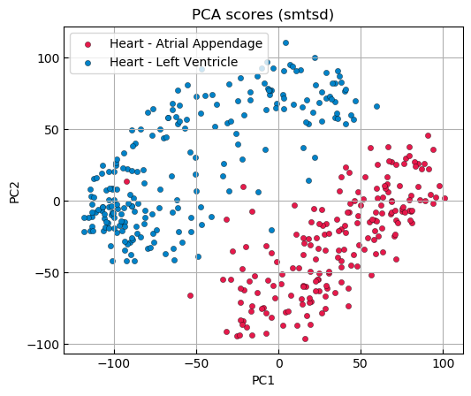

```julia
pcaplots((Eps./Sigma_Eps)',sample_info[!,[:smtsd]]);
```

For comparison, we could also run PCA on the log-transformed TPMs:

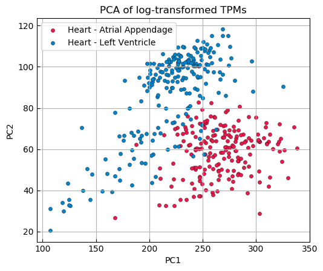

```julia
# Compute standard normalizations for comparison
RPM, RPKM, TPM = standard_normalizations(Y, gene_info[!,:seq_len])
pcaplots(log.(TPM.+1)',sample_info[!,[:smtsd]])
title("PCA of log-transformed TPMs");
```

## Exploring sample covariates using residuals

To explore relationships in the data, it is useful to color plots like this using a variety of covariates. We illustrate coloring this plot using one more categorical covariate (`smcenter` = sample collection center) and two numeric covariates (`exr` = exonic rate, and `rin` = RNA integrity number).

One must be careful to avoid finding spurious relationships, so in practice we recommend splitting the data into an exploratory subset and a testing subset, when possible (e.g., see Miller and Carter, 2020). That way, one can inspect any number of plots like this using the exploratory subset, select a model based on this exploratory phase, and then perform statistically valid hypothesis tests on the testing data.

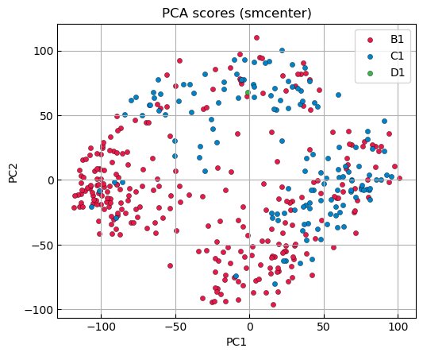

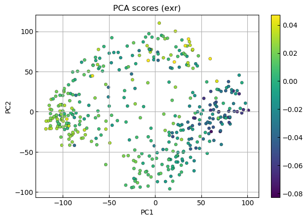

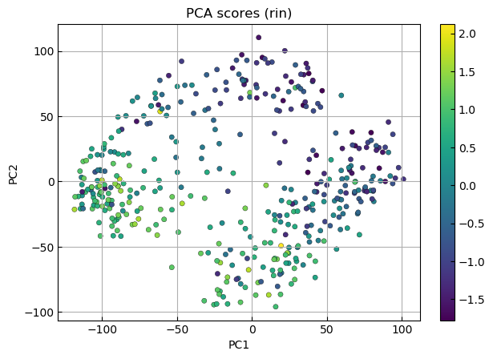

```julia
# Visualize association with sample covariates
pcaplots((Eps./Sigma_Eps)',sample_info[!,[:smcenter,:exr,:rin]]);
```

## Adjusting for sample covariates

Often, there are unwanted sources of variation that one would like to remove, such as technical biases. In the PCA plots of the residuals for the simple normalization model in Equation (2), there is clearly some association with `smcenter`, `exr`, and `rin` which could be due to technical batch effects. Since the `exr` and `rin` associations seems clearer and provide a plausible explanation for the `smcenter` effect, we consider adjusting for `exr` and `rin` as an example.

To add sample covariates to a GBM, we simply add columns to the $Z$ matrix. That said, it is important to note that every additional sample covariate increases the dimension of the parameter space by $I$, since $Z\in\mathbb{R}^{J\times L}$ and $B\in\mathbb{R}^{I\times L}$. Thus, when $I$ is large and $J$ is small, one must be judicious in the choice of which sample covariates to include, since otherwise overfitting can occur.

The code below uses `exr`, `rin`, `exr`$^2$, `rin`$^2$ as sample covariates. The `@formula` syntax from the `GLM` package provides a convenient way to specify design matrices, similar to the formulas used with `lm` in the R programming language. Here, the dependent variable `y` in the formula is just an arbitrary symbol.

```julia
X = ones(I,1)  # feature covariate matrix
Z,Znames = design_matrix(@formula(y ~ 1 + exr*exr + rin*rin), sample_info)  # sample covariate matrix
M = 0  # number of latent factors

Znames  # names of the columns of Z
```

```
5-element Array{String,1}:
 "(Intercept)"
 "exr"
 "rin"
 "exr & exr"
 "rin & rin"
```

```julia
A,B,C,D,U,V,S,T,omega,logp = BilinearModels.fit(Y,X,Z,M)
Eps_s,Sigma_Eps_s = BilinearModels.residuals(Y,X,Z,A,B,C,D,U,V,S,T,omega);
```

```
 max step size enforced in S[i] update for one or more i.
 max step size enforced in A[j,:] update for one or more j.
iteration 1: logp = -4.5316321503891446e7
 max step size enforced in A[j,:] update for one or more j.
 max step size enforced in S[i] update for one or more i.
iteration 2: logp = -4.52538804080506e7
 max step size enforced in A[j,:] update for one or more j.
iteration 3: logp = -4.523603105410502e7
iteration 4: logp = -4.5228491115534686e7
iteration 5: logp = -4.522411856533155e7
iteration 6: logp = -4.522110121210874e7
iteration 7: logp = -4.5218880482276335e7
iteration 8: logp = -4.5217179070288174e7
iteration 9: logp = -4.521583153629001e7
iteration 10: logp = -4.521473455946487e7
iteration 11: logp = -4.521383586476797e7
iteration 12: logp = -4.521310946381896e7
iteration 13: logp = -4.5212537014571615e7
iteration 14: logp = -4.521208875011572e7
iteration 15: logp = -4.521172868402331e7
iteration 16: logp = -4.521141799093374e7
iteration 17: logp = -4.521114316785886e7
iteration 18: logp = -4.5210892701831646e7
iteration 19: logp = -4.521066840726619e7
iteration 20: logp = -4.521047088544427e7
iteration 21: logp = -4.52103195660591e7
iteration 22: logp = -4.52102238443791e7
iteration 23: logp = -4.521018030014335e7
Finished.
```

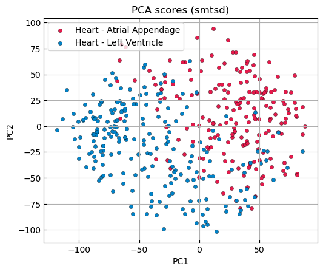

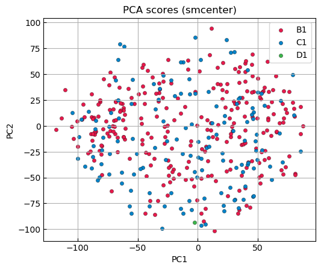

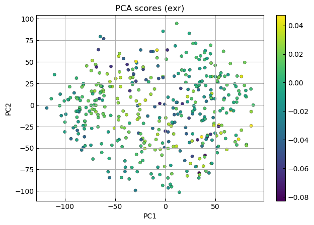

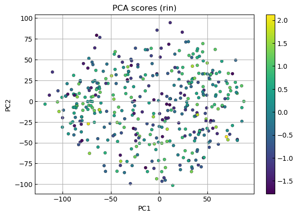

```julia
pcaplots((Eps_s./Sigma_Eps_s)',sample_info[!,[:smtsd,:smcenter,:exr,:rin]]);
```

After adjusting for these covariates, the association with sequencing center (`smcenter`) appears to have been largely removed.

## Exploring feature covariates using residuals

Similarly, we can explore possible associations with feature covariates using the model residuals. To illustrate this, we start again with the residuals from the simple normalization model in Equation (2).

To visualize each gene as a point, we could perform PCA on `Eps` and plot the top two PCs as usual. However, the figure below shows that this yields a highly skewed scatterplot. To understand why, we color each gene using its log-transformed mean precision across samples (`lmp`), which makes it clear that the widely varying precision across genes is the reason for the skewness.

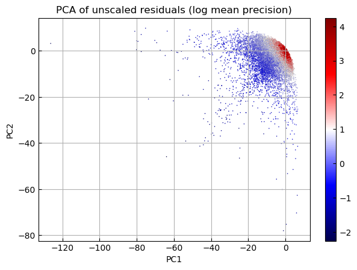

```julia
lmp = vec(log.(mean(1.0./Sigma_Eps.^2, dims=2)))
pcaplots(Eps, DataFrame("lmp"=>lmp); s=1, lw=0.05, cmap="seismic")
title("PCA of unscaled residuals (log mean precision)");
```

To fix this, we instead perform PCA on the scaled residuals `Eps./Sigma_Eps` as recommended above, which uses the matrix of estimated residual standard deviations `Sigma_Eps` to downweight low precision residuals on an entry-by-entry basis.

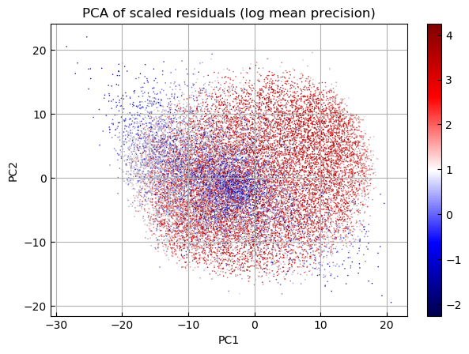

```julia
pcaplots(Eps./Sigma_Eps, DataFrame("lmp"=>lmp); s=1, lw=0.05, cmap="seismic")
title("PCA of scaled residuals (log mean precision)");
```

Using these scaled residuals, we explore a few possible gene covariates.

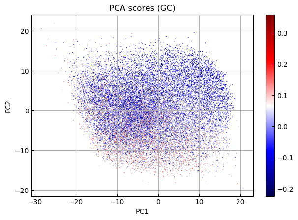

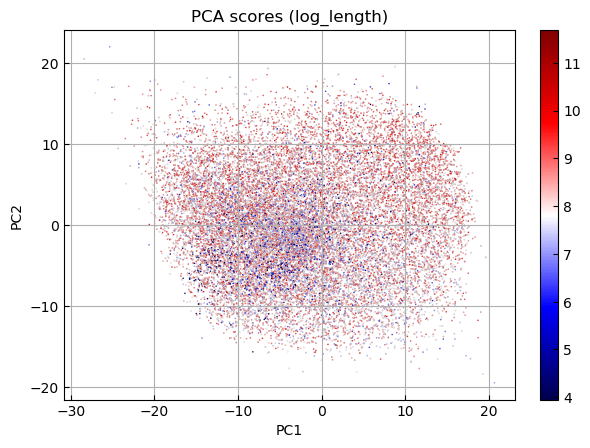

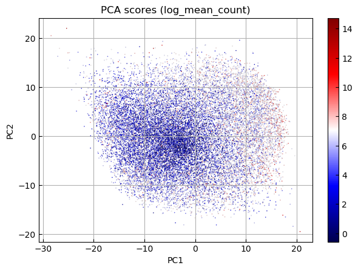

```julia
scores = pcaplots(Eps./Sigma_Eps, gene_info[!,[:GC,:log_length,:log_mean_count]]; s=1, lw=0.05, cmap="seismic");
```

Visually, `log_mean_count` appears to be slightly associated with PC1, whereas `GC` appears to have a moderate association with PC2. This can be verified quantitatively:

```julia
cor(scores, gene_info[!,:log_mean_count])
```

```
2×1 Array{Float64,2}:
 0.2727658377709529
 0.08665780191440087
```

```julia
cor(scores, gene_info[!,:GC])
```

```
2×1 Array{Float64,2}:
 -0.1053559639996449
 -0.3894242515730472
```

## Adjusting for feature covariates

In sequencing data, there are often technical biases associated with feature covariates such as GC content. Indeed, the PCA plot provides some evidence for moderate GC bias in the GTEx heart data.

To add feature covariates to a GBM, we simply add columns to the $X$ matrix. As in the case of sample covariates, one needs to be careful not to overfit. Fortunately, though, in the case of feature covariates, overfitting is less of an issue when $I$ is large relative to $J$, because the dimension of the parameter space only increases by $J$ with each additional feature covariate.

Here, we illustrate adjusting for `log_mean_count`, `GC`, and `GC`$^2$. The associations with these variables are effectively removed after adjustment.

```julia
X,Xnames = design_matrix(@formula(y ~ 1 + log_mean_count + GC*GC), gene_info)  # feature covariate matrix
Z = ones(J,1)  # sample covariate matrix
M = 0  # number of latent factors

A,B,C,D,U,V,S,T,omega,logp = BilinearModels.fit(Y,X,Z,M)
Eps,Sigma_Eps = BilinearModels.residuals(Y,X,Z,A,B,C,D,U,V,S,T,omega);
```

```
 max step size enforced in S[i] update for one or more i.
 max step size enforced in S[i] update for one or more i.
 max step size enforced in S[i] update for one or more i.
 max step size enforced in A[j,:] update for one or more j.
 max step size enforced in S[i] update for one or more i.
iteration 1: logp = -4.560609910947748e7
iteration 2: logp = -4.5562047030521296e7
iteration 3: logp = -4.5550504282477275e7
iteration 4: logp = -4.554676670378464e7
iteration 5: logp = -4.5546125721742325e7
iteration 6: logp = -4.554609984691751e7
Finished.
```

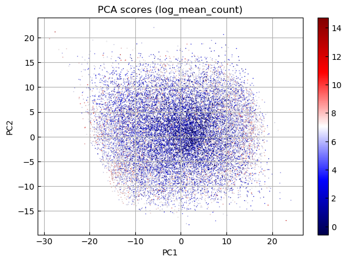

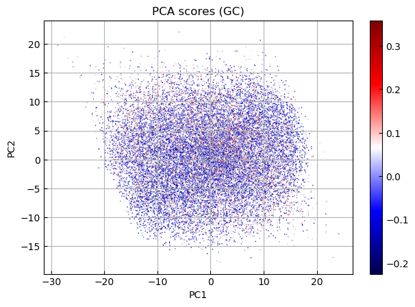

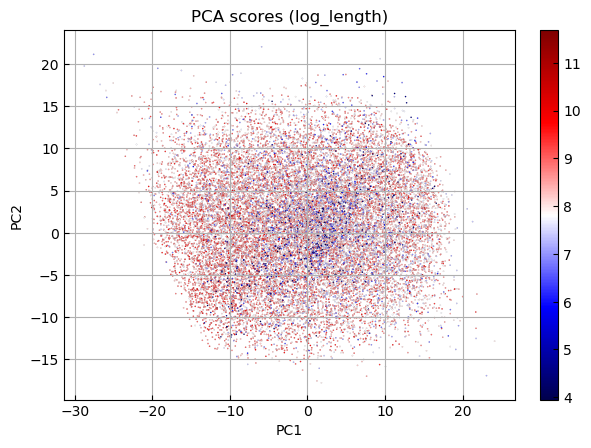

```julia
pcaplots(Eps./Sigma_Eps, gene_info[!,[:log_mean_count,:GC,:log_length]]; s=1, lw=0.05, cmap="seismic");
```

## Testing for differences between groups

In gene expression analysis, a common task is testing for differential expression between two groups of samples. In more general terms, this consists of performing a hypothesis test for whether there is a difference between two sample conditions, with respect to each feature, adjusting for covariates and latent factors.

In a GBM, we do this by including a sample covariate that is a binary indicator of the sample condition to be tested. If this covariate is in column $\ell$ of the $Z$ matrix, then for feature $i$, the null hypothesis of no difference is that $b_{i \ell} = 0$. To perform a Wald test for $H_0 : b_{i \ell} = 0$ versus $H_1 : b_{i \ell} \neq 0$, the p-value can be computed as

$$ p_i = 2 \big(1 - \Phi(|\hat{b}_{i \ell} / \hat{\mathrm{se}}(b_{i \ell})|)\big) $$

where $\Phi(x)$ is the standard normal CDF, $\hat{b}_{i \ell}$ is the estimate of $b_{i \ell}$, and $\hat{\mathrm{se}}(b_{i \ell})$ is an approximate standard error for this estimate.

We illustrate by testing for differential expression between the "Heart - Left Ventricle" and "Heart - Atrial Appendage" subtissues. To do so, we augment the sample covariate matrix to include subtissue type (`smtsd`). We also keep the other sample and gene covariates, to adjust for unwanted technical effects. For now, we use no latent factors.

```julia
X,Xnames = design_matrix(@formula(y ~ 1 + log_mean_count + GC*GC), gene_info)
Z,Znames = design_matrix(@formula(y ~ 1 + exr*exr + rin*rin + smtsd), sample_info)  # add smtsd (subtissue type)
M = 0;  # number of latent factors
```

We fit the model just as before, and then we also run the `infer` function on the output of the `fit` function:

```julia
A,B,C,D,U,V,S,T,omega,logp = BilinearModels.fit(Y,X,Z,M)  # fit the model

se_A,se_B,se_C,se_U,se_V,se_S,se_T = BilinearModels.infer(Y,X,Z,A,B,C,D,U,V,S,T,omega);  # compute standard errors
```

```
 max step size enforced in S[i] update for one or more i.
 max step size enforced in A[j,:] update for one or more j.
iteration 1: logp = -4.4290344903716855e7
 max step size enforced in A[j,:] update for one or more j.
 max step size enforced in S[i] update for one or more i.
iteration 2: logp = -4.426736618421439e7
 max step size enforced in A[j,:] update for one or more j.
 max step size enforced in S[i] update for one or more i.
iteration 3: logp = -4.42531558027156e7
 max step size enforced in A[j,:] update for one or more j.
 max step size enforced in S[i] update for one or more i.
iteration 4: logp = -4.4248392508271545e7
 max step size enforced in A[j,:] update for one or more j.
iteration 5: logp = -4.424529101136171e7
iteration 6: logp = -4.4243307097839184e7
iteration 7: logp = -4.4241933125429615e7
iteration 8: logp = -4.424091480704195e7
iteration 9: logp = -4.4240163605807155e7
iteration 10: logp = -4.423961335591716e7
iteration 11: logp = -4.423919835475349e7
iteration 12: logp = -4.423887844078973e7
iteration 13: logp = -4.42386296128876e7
iteration 14: logp = -4.423843747899055e7
iteration 15: logp = -4.4238300609904006e7
iteration 16: logp = -4.423821303098103e7
iteration 17: logp = -4.423817732902787e7
Finished.
```

```julia
varname = "smtsd"
varindex = findfirst([split(n,":")[1]==varname for n in Znames])  # column of Z with the covariate of interest
zscores = B[:,varindex] ./ se_B[:,varindex]
logpvalues = log(2) .+ logccdf.(Normal(0,1), abs.(zscores))

println("Number of p-values significant at p < 0.05 after Bonferroni correction: ",sum(logpvalues .< log(0.05/I)))
```

```
Number of p-values significant at p < 0.05 after Bonferroni correction: 10834
```

This indicates widespread differences between these two subtissues, with 10,834 out of 20,088 genes being detected as significantly differentially expressed, controlling family wise error rate (FWER) at 0.05 using the Bonferonni correction. These p-values or the list of most significant genes can be used for downstream analyses such as enrichment of KEGG pathways or GO term gene sets.

## Testing for association, adjusting for covariates and latent factors

More generally, one may want to test whether the data exhibit significant associations with a particular covariate. Differential expression is a special case in which the covariate is a binary indicator of group membership, however, the same method can be used with arbitrary discrete or continuous covariates. Often, it is important to adjust not only for other observed covariates, but also for latent factors that may represent unobserved covariates such as batch effects.

```julia
X,Xnames = design_matrix(@formula(y ~ 1 + log_mean_count + GC*GC), gene_info)
Z,Znames = design_matrix(@formula(y ~ 1 + exr*exr + rin*rin + age_numeric), sample_info)
M = 4;  # number of latent factors
```

```julia
A,B,C,D,U,V,S,T,omega,logp = BilinearModels.fit(Y,X,Z,M)

se_A,se_B,se_C,se_U,se_V,se_S,se_T = BilinearModels.infer(Y,X,Z,A,B,C,D,U,V,S,T,omega);  # compute standard errors
```

```
 max step size enforced in S[i] update for one or more i.
 max step size enforced in A[j,:] update for one or more j.
iteration 1: logp = -4.494781958116342e7
 max step size enforced in A[j,:] update for one or more j.
 max step size enforced in G[i,:] update for one or more i.
 max step size enforced in G[i,:] update for one or more i.
 max step size enforced in S[i] update for one or more i.
iteration 2: logp = -4.389272373163933e7
 max step size enforced in A[j,:] update for one or more j.
 max step size enforced in G[i,:] update for one or more i.
 max step size enforced in G[i,:] update for one or more i.
iteration 3: logp = -4.35798899317798e7
 max step size enforced in G[i,:] update for one or more i.
 max step size enforced in G[i,:] update for one or more i.
iteration 4: logp = -4.346216110741093e7
 max step size enforced in G[i,:] update for one or more i.
 max step size enforced in G[i,:] update for one or more i.
iteration 5: logp = -4.340890602778917e7
 max step size enforced in G[i,:] update for one or more i.
 max step size enforced in G[i,:] update for one or more i.
iteration 6: logp = -4.338654072885635e7
 max step size enforced in G[i,:] update for one or more i.
 max step size enforced in G[i,:] update for one or more i.
iteration 7: logp = -4.337552056202056e7
 max step size enforced in G[i,:] update for one or more i.
 max step size enforced in G[i,:] update for one or more i.
iteration 8: logp = -4.336819272970707e7
 max step size enforced in G[i,:] update for one or more i.
 max step size enforced in G[i,:] update for one or more i.
iteration 9: logp = -4.3362239433316536e7
 max step size enforced in G[i,:] update for one or more i.
 max step size enforced in G[i,:] update for one or more i.
iteration 10: logp = -4.33574044044301e7
 max step size enforced in G[i,:] update for one or more i.
 max step size enforced in G[i,:] update for one or more i.
iteration 11: logp = -4.335291293026611e7
iteration 12: logp = -4.334877900112451e7
iteration 13: logp = -4.334516683574122e7
iteration 14: logp = -4.334227889027575e7
iteration 15: logp = -4.334005683255982e7
iteration 16: logp = -4.333835868189632e7
iteration 17: logp = -4.3337048194130205e7
iteration 18: logp = -4.3335985135339364e7
iteration 19: logp = -4.333505698129356e7
iteration 20: logp = -4.333421033243025e7
iteration 21: logp = -4.333342627450253e7
iteration 22: logp = -4.333269706433166e7
iteration 23: logp = -4.33320119722638e7
iteration 24: logp = -4.3331373974900484e7
iteration 25: logp = -4.333080982323061e7
iteration 26: logp = -4.333035334689327e7
iteration 27: logp = -4.3330031730928265e7
iteration 28: logp = -4.332984631672294e7
iteration 29: logp = -4.3329770789134555e7
iteration 30: logp = -4.3329751428186506e7
Finished.
```

```julia
# Test for association with age
varname = "age_numeric"
varindex = findfirst([split(name,":")[1]==varname for name in Znames])  # column of Z with the covariate of interest
zscores = B[:,varindex] ./ se_B[:,varindex]
logpvalues = log(2) .+ logccdf.(Normal(0,1), abs.(zscores))

println("Number of p-values significant at p < 0.05 after Bonferroni correction: ",sum(logpvalues .< log(0.05/I)))
```

```
Number of p-values significant at p < 0.05 after Bonferroni correction: 454
```

```julia
# Rank genes by their p-values
order = sortperm(logpvalues)
gene_results = gene_info[order,[:id,:symbol,:seqname]]
gene_results[!,:pvalue] = exp.(logpvalues[order])
gene_results[!,:benjamini] = benjamini_hochberg(gene_results[!,:pvalue])
hits = findall(gene_results[!,:benjamini] .< 0.05)
gene_results[hits[1:15],:]

# To save these lists of genes to file:
#CSV.write("hits-M=$M-top1000.txt",gene_results[hits[1:min(1000,end)],[:id]]; writeheader=false)
#CSV.write("background_list.txt",gene_info[!,[:id]]; writeheader=false)
```

|  | id SubStri… | symbol String | seqname String | pvalue Float64 | benjamini Float64 |
| --- | --- | --- | --- | --- | --- |
| 1 | ENSG00000131080 | EDA2R | chrX | 4.65578e-24 | 9.35253e-20 |
| 2 | ENSG00000048540 | LMO3 | chr12 | 1.49197e-23 | 1.49853e-19 |
| 3 | ENSG00000188783 | PRELP | chr1 | 5.90127e-21 | 3.95149e-17 |
| 4 | ENSG00000124343 | XG;XGY2 | chrX | 1.98947e-18 | 9.99112e-15 |
| 5 | ENSG00000105664 | COMP | chr19 | 3.94509e-17 | 1.58498e-13 |
| 6 | ENSG00000130513 | GDF15 | chr19 | 7.7639e-17 | 2.59935e-13 |
| 7 | ENSG00000163071 | SPATA18 | chr4 | 1.09549e-16 | 3.14373e-13 |
| 8 | ENSG00000154767 | XPC | chr3 | 4.31167e-16 | 1.08266e-12 |
| 9 | ENSG00000244694 | PTCHD4 | chr6 | 4.4987e-16 | 1.00411e-12 |
| 10 | ENSG00000164089 | ETNPPL | chr4 | 8.39168e-16 | 1.68572e-12 |
| 11 | ENSG00000122176 | FMOD | chr1 | 5.24094e-15 | 9.57091e-12 |
| 12 | ENSG00000206195 | DUXAP8;LINC01296 | chr22 | 4.85228e-14 | 8.12272e-11 |
| 13 | ENSG00000101892 | ATP1B4 | chrX | 4.98479e-14 | 7.70265e-11 |
| 14 | ENSG00000188906 | LRRK2 | chr12 | 5.93633e-14 | 8.51779e-11 |
| 15 | ENSG00000118523 | CTGF | chr6 | 6.36163e-14 | 8.51949e-11 |

## Computing partial residuals

It is often useful to compute partial residuals in which some effects are adjusted out, but some are retained. The `residuals` function enables one to retain selected effects by using the optional arguments `rx`, `rz`, and `ru`.

For example, when testing for age-associated genes, it is helpful to visualize the relationship between age and estimated expression. A natural way of defining estimated expression is via the partial residual

$$ \hat{c}_{1 1} + \hat{a}_{j 1} + \hat{b}_{i 1} + (\hat{c}_{1 \ell} + \hat{b}_{i \ell}) z_{j \ell} + \varepsilon_{i j} $$

where $\ell$ is the index of the `age_numeric` column in $Z$, and $\varepsilon_{i j} = \log(Y_{i j} + \epsilon) - \log(\mathrm{E}(Y_{i j}))$ is the GBM residual as defined earlier.

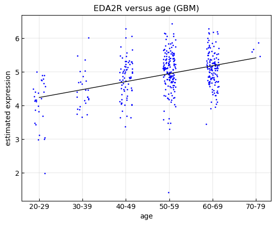

```julia
# (Continuing from the previous part, using the estimated parameters.)

# Compute partial residuals
rx = [1]           # retain these columns of X in residuals (do not adjust them out)
rz = [1,varindex]  # retain these columns of Z in residuals (do not adjust them out)
Eps,Sigma_Eps = BilinearModels.residuals(Y,X,Z,A,B,C,D,U,V,S,T,omega; rx=rx, rz=rz)

# Age variables for plotting
age = sample_info[!,:age_numeric]
unique_ages = sort(unique(sample_info[!,:age_numeric]))
unique_ages_names = sort(unique(sample_info[!,:age]))

# Plot estimated expression versus age for top hit, using GBM residuals
figure(); clf(); grid(true)
plot_association(age,Eps[order[1],:],unique_ages,unique_ages_names; showline=true)
title("$(gene_info[order[1],:symbol]) versus age (GBM)")
xlabel("age"); ylabel("estimated expression");
```

This plot shows the partial residuals for the top gene hit (EDA2R), retaining the effect of age (and the intercepts) while adjusting out all other covariates and latent factors.

## Dimension reduction using latent factors

In addition to adjusting out unwanted sources of hidden variation, the GBM latent factors can be used to discover interesting sources of hidden variation. Up to now in this tutorial, we have used PCA on the residuals to perform dimension reduction, however, PCA implicitly assumes the residuals are normally distributed with common variance. While the scaled residuals are intended to make this approximation reasonable, the GBM latent factors provide a more principled, model-based approach to dimension reduction.

Computing GBM latent factors is slower than running PCA on the residuals, but it tends to yield noticably better results in our experience. The improvement is presumably due to the fact that they are estimated using the model likelihood rather than using least squares on the residuals as in PCA.

To illustrate, we first consider the estimated parameters from the model that was used to test for age-associated genes (i.e., the current model from the preceding sections). Since two dimensions are convenient for visualization, we illustrate by plotting the first two latent factors. Specifically, the first and second columns of $V$ are roughly analogous to the first and second principal components scores, respectively.

More generally, the rows of $V$ provide a low-dimensional representation of the samples that can be used for visualization or downstream analyses.

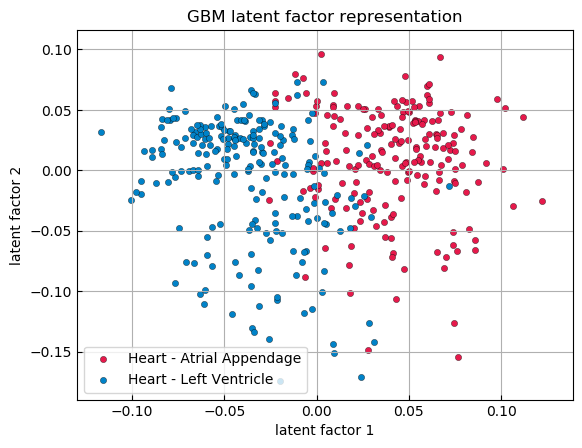

```julia
# (Continuing from the previous part, using the estimated parameters.)

figure(); clf(); grid(true)
plotgroups(V[:,1],V[:,2],sample_info[!,:smtsd]; s=20, ec="k", lw=0.25)
title("GBM latent factor representation")
xlabel("latent factor 1"); ylabel("latent factor 2"); legend();
```

```julia
cor(V, sample_info[!,:smtsd] .== "Heart - Left Ventricle")
```

```
4×1 Array{Float64,2}:
 -0.7942619222049782
 -0.1615197565879846
  0.09654349997424791
 -0.01754917959244648
```

Here, the first latent factor is strongly associated with the subtissue type.

To see the difference between using the GBM latent factors compared to PCA on the residuals, we refit the model with no latent factors ($M = 0$), and run PCA on the residuals:

```julia
X,Xnames = design_matrix(@formula(y ~ 1 + log_mean_count + GC*GC), gene_info)
Z,Znames = design_matrix(@formula(y ~ 1 + exr*exr + rin*rin + age_numeric), sample_info)
M = 0  # number of latent factors
A,B,C,D,U,V,S,T,omega,logp = BilinearModels.fit(Y,X,Z,M)
Eps,Sigma_Eps = BilinearModels.residuals(Y,X,Z,A,B,C,D,U,V,S,T,omega);
```

```
 max step size enforced in S[i] update for one or more i.
 max step size enforced in A[j,:] update for one or more j.
iteration 1: logp = -4.489359899521883e7
 max step size enforced in A[j,:] update for one or more j.
 max step size enforced in S[i] update for one or more i.
iteration 2: logp = -4.48504557450764e7
 max step size enforced in A[j,:] update for one or more j.
iteration 3: logp = -4.483360151491037e7
 max step size enforced in A[j,:] update for one or more j.
iteration 4: logp = -4.482669947824478e7
iteration 5: logp = -4.482281777238019e7
iteration 6: logp = -4.4820073232070744e7
iteration 7: logp = -4.48179795485585e7
iteration 8: logp = -4.481631412957241e7
iteration 9: logp = -4.4814961007605255e7
iteration 10: logp = -4.481383624300148e7
iteration 11: logp = -4.481289415726053e7
iteration 12: logp = -4.481210743284237e7
iteration 13: logp = -4.481144769682484e7
iteration 14: logp = -4.481089974598575e7
iteration 15: logp = -4.481044688255441e7
iteration 16: logp = -4.481006754527267e7
iteration 17: logp = -4.480974291016477e7
iteration 18: logp = -4.480945317572053e7
iteration 19: logp = -4.48091833309651e7
iteration 20: logp = -4.480892897614139e7
iteration 21: logp = -4.4808696547773115e7
iteration 22: logp = -4.4808494945279546e7
iteration 23: logp = -4.4808339398230605e7
iteration 24: logp = -4.480823159677684e7
iteration 25: logp = -4.4808165688219786e7
iteration 26: logp = -4.4808130887410134e7
Finished.
```

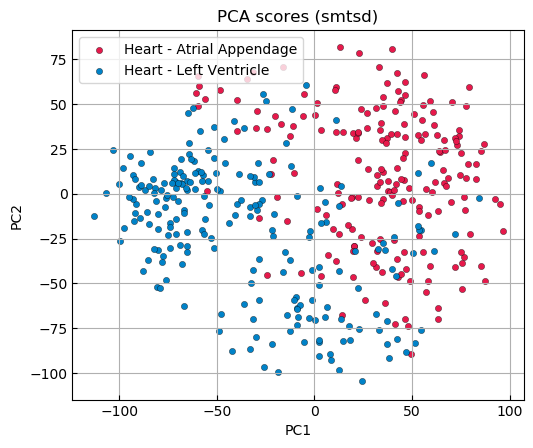

```julia
pcaplots((Eps./Sigma_Eps)',sample_info[!,[:smtsd]]);
```

The clusters in the GBM latent factor representation are noticably tighter than when using PCA on the residuals. Further, subtissue type is strongly associated with the first latent factor, and only weakly associated with the other latent factors. Thus, in this example, the first latent factor has a somewhat clearer biological interpretation than the first principal component. Note that the model has not been given the subtissue type indicators in this example.

## References

Choulakian, V. **Generalized bilinear models.** Psychometrika, 61(2):271–283, 1996.

Collado-Torres, L., Nellore, A., Kammers, K., Ellis, S. E., Taub, M. A., Hansen, K. D., Jaffe, A. E., Langmead, B., and Leek, J. T. **Reproducible RNA-seq analysis using recount2.** Nature Biotechnology, 35(4):319–321, 2017.

Melé, M., Ferreira, P. G., Reverter, F., DeLuca, D. S., Monlong, J., Sammeth, M., Young, T. R., Goldmann, J. M., Pervouchine, D. D., Sullivan, T. J., et al. **The human transcriptome across tissues and individuals.** Science, 348(6235):660–665, 2015.

Miller, J. W. and Carter, S. L. **Inference in generalized bilinear models.** [arXiv preprint: arXiv2010.04896](https://arxiv.org/abs/2010.04896), 2020.

This file is released under the MIT "Expat" License.  
Copyright (c) 2020: Jeffrey W. Miller.